# Homework #3.2

```python
%matplotlib inline
import warnings
warnings.filterwarnings('ignore')
import numpy as np
import pandas as pd
import matplotlib.pyplot as plt
import statsmodels.api as sm
from statsmodels.stats.diagnostic import het_white
from arch import arch_model

pd.set_option('display.max_rows', 500)
```

```python
# read data
macro = pd.read_excel('data/hw_3_2_data.xlsx', sheet_name='macro')
sp500 = pd.read_excel('data/hw_3_2_data.xlsx', sheet_name="s&p500")
```

# 1. Assessing the OLS Model

### 1. OLS Regression CPI and Money

```python
X = macro.M2
y = macro.CPI
model = sm.OLS(y, sm.add_constant(X))
results = model.fit()
results.summary()
```

OLS Regression Results

| Dep. Variable: | CPI | R-squared: | 0.827 |
| --- | --- | --- | --- |
| Model: | OLS | Adj. R-squared: | 0.827 |
| Method: | Least Squares | F-statistic: | 3618. |
| Date: | Sun, 26 Jun 2022 | Prob (F-statistic): | 8.42e-291 |
| Time: | 23:02:24 | Log-Likelihood: | -3721.7 |
| No. Observations: | 760 | AIC: | 7447. |
| Df Residuals: | 758 | BIC: | 7457. |
| Df Model: | 1 |  |  |
| Covariance Type: | nonrobust |  |  |

|  | coef | std err | t | P>\|t\| | [0.025 | 0.975] |
| --- | --- | --- | --- | --- | --- | --- |
| const | 62.7397 | 1.645 | 38.145 | 0.000 | 59.511 | 65.969 |
| M2 | 0.0145 | 0.000 | 60.151 | 0.000 | 0.014 | 0.015 |

| Omnibus: | 42.247 | Durbin-Watson: | 0.001 |
| --- | --- | --- | --- |
| Prob(Omnibus): | 0.000 | Jarque-Bera (JB): | 36.033 |
| Skew: | -0.458 | Prob(JB): | 1.50e-08 |
| Kurtosis: | 2.454 | Cond. No. | 9.54e+03 |

Notes:  
[1] Standard Errors assume that the covariance matrix of the errors is correctly specified.  
[2] The condition number is large, 9.54e+03. This might indicate that there are  
strong multicollinearity or other numerical problems.

a) $R^{2} = 0.827$  
b) $\beta = 0.0145$

### 2- Regression of growth rates

```python
inflation = macro.set_index('date')[['CPI', 'M2']].pct_change(12, freq='M').reset_index().dropna()
X = inflation.M2
y = inflation.CPI
model = sm.OLS(y, sm.add_constant(X)).fit()
model.summary()
```

OLS Regression Results

| Dep. Variable: | CPI | R-squared: | 0.008 |
| --- | --- | --- | --- |
| Model: | OLS | Adj. R-squared: | 0.007 |
| Method: | Least Squares | F-statistic: | 6.370 |
| Date: | Sun, 26 Jun 2022 | Prob (F-statistic): | 0.0118 |
| Time: | 23:02:24 | Log-Likelihood: | 1610.0 |
| No. Observations: | 748 | AIC: | -3216. |
| Df Residuals: | 746 | BIC: | -3207. |
| Df Model: | 1 |  |  |
| Covariance Type: | nonrobust |  |  |

|  | coef | std err | t | P>\|t\| | [0.025 | 0.975] |
| --- | --- | --- | --- | --- | --- | --- |
| const | 0.0320 | 0.002 | 13.839 | 0.000 | 0.027 | 0.037 |
| M2 | 0.0729 | 0.029 | 2.524 | 0.012 | 0.016 | 0.130 |

| Omnibus: | 211.421 | Durbin-Watson: | 0.020 |
| --- | --- | --- | --- |
| Prob(Omnibus): | 0.000 | Jarque-Bera (JB): | 484.782 |
| Skew: | 1.517 | Prob(JB): | 5.38e-106 |
| Kurtosis: | 5.519 | Cond. No. | 28.2 |

Notes:  
[1] Standard Errors assume that the covariance matrix of the errors is correctly specified.

a) $R^{2} = 0.008$  
b) $\beta = 0.0729$

### 3- Discussion

The correlation between CPI and Money seems to be stronger than the correlation between inflation and money growth.  
However, CPI is non-stationary and will tend to have a strong correlation with anything that has an upward trend. Which in this case is Money.  
Hence, the correlation observed here could be spurious. Regressing CPI on Money doesn't make sense.

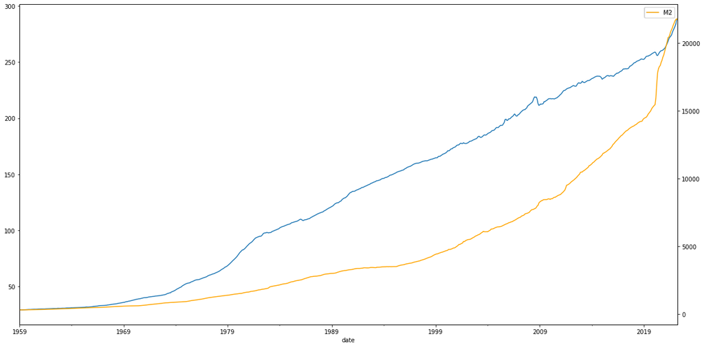

```python
fig, ax1 = plt.subplots()
macro.set_index('date')[['CPI']].plot(figsize=(20, 10), ax=ax1)
ax2 = ax1.twinx()
macro.set_index('date')[['M2']].plot(figsize=(20, 10), ax=ax2, c='orange')
```

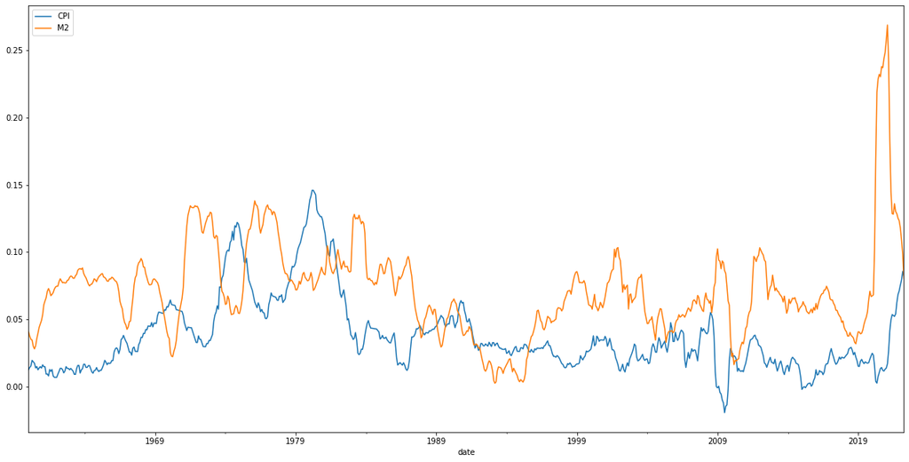

```python
inflation.set_index('date')[['CPI', 'M2']].plot(figsize=(20, 10))
```

## 4.

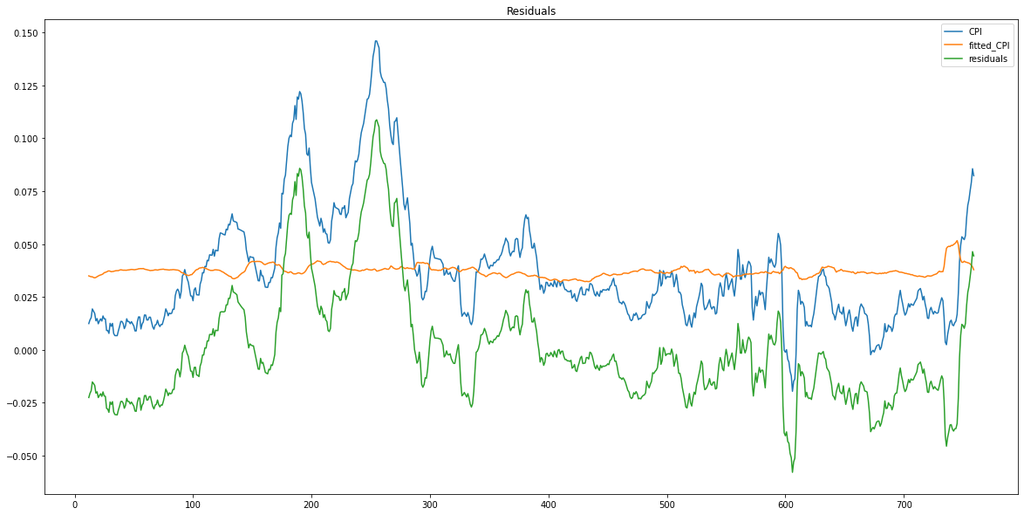

```python
predicted = pd.concat([y, pd.DataFrame(data=model.predict(sm.add_constant(X)), index=X.index, columns=['fitted_CPI'])],axis=1)
predicted['residuals'] = predicted['CPI'] - predicted['fitted_CPI']
predicted.plot(title='Residuals', figsize=(20, 10))
```

a) The residuals don't seem to be drawn from a constant variance.  
b) They do seem to have some serial correlation.

## 5.

a) Looking at the reported p-values from 2. $\alpha$ and $\beta$ estimates seem to be statistically significant.  
b) Yes, given that the homoscedasticity assumption doesn't hold the standard error is misspecified.  
c) The estimated $\beta$ would be more thrustworthy for larger sample sizes.

## 6.

a) From 2. the Durbin-Watson value is 0.020 which indicates presence of serial correlation.  
b) Using White test (see below), we have an extremely small $p-value=9.75*10^{-5}$ which means that the errors aren't homoscedastic.

```python
white_test = het_white(model.resid,  model.model.exog)
labels = ['LM Statistic', 'LM-Test p-value', 'F-Statistic', 'F-Test p-value']
print(dict(zip(labels, white_test)))
```

```
{'LM Statistic': 18.469958814741208, 'LM-Test p-value': 9.756620279329117e-05, 'F-Statistic': 9.43081061790568, 'F-Test p-value': 9.020683988503916e-05}
```

# 2. Forecasting via Regression

```python
# build dataset
def build_dataset(h, macro):
    inflation = macro.set_index('date')[['CPI', 'M2']].pct_change(h, freq='M').reset_index().dropna()
    inflation['y'] = inflation.set_index('date')['CPI'].shift(h, freq='M').reset_index().CPI
    return inflation.dropna()

def fit_model(y, X):
    return sm.OLS(y, sm.add_constant(X)).fit()
```

### 1. Forcast using lagged infation

```python
h_values = [1, 12, 24, 36]
for h in h_values:
    inflation_lagged = build_dataset(h, macro)
    results = fit_model(inflation_lagged['y'], inflation_lagged['CPI'])
    print(f'\n\n\t######################## Results for h={h} ########################\n{results.summary()}')
```

```
	######################## Results for h=1 ########################
                            OLS Regression Results
==============================================================================
Dep. Variable:                      y   R-squared:                       0.399
Model:                            OLS   Adj. R-squared:                  0.398
Method:                 Least Squares   F-statistic:                     501.8
Date:                Sun, 26 Jun 2022   Prob (F-statistic):           1.22e-85
Time:                        23:02:27   Log-Likelihood:                 3482.7
No. Observations:                 758   AIC:                            -6961.
Df Residuals:                     756   BIC:                            -6952.
Df Model:                           1
Covariance Type:            nonrobust
==============================================================================
                 coef    std err          t      P>|t|      [0.025      0.975]
------------------------------------------------------------------------------
const          0.0011      0.000      9.115      0.000       0.001       0.001
CPI            0.6312      0.028     22.401      0.000       0.576       0.686
==============================================================================
Omnibus:                       92.917   Durbin-Watson:                   2.143
Prob(Omnibus):                  0.000   Jarque-Bera (JB):              798.226
Skew:                           0.113   Prob(JB):                    4.65e-174
Kurtosis:                       8.022   Cond. No.                         317.
==============================================================================

Notes:
[1] Standard Errors assume that the covariance matrix of the errors is correctly specified.


	######################## Results for h=12 ########################
                            OLS Regression Results
==============================================================================
Dep. Variable:                      y   R-squared:                       0.555
Model:                            OLS   Adj. R-squared:                  0.555
Method:                 Least Squares   F-statistic:                     917.1
Date:                Sun, 26 Jun 2022   Prob (F-statistic):          2.40e-131
Time:                        23:02:27   Log-Likelihood:                 1877.3
No. Observations:                 736   AIC:                            -3751.
Df Residuals:                     734   BIC:                            -3741.
Df Model:                           1
Covariance Type:            nonrobust
```

[output cut: 55 more lines]

```
Covariance Type:            nonrobust
==============================================================================
                 coef    std err          t      P>|t|      [0.025      0.975]
------------------------------------------------------------------------------
const          0.0507      0.004     11.476      0.000       0.042       0.059
CPI            0.5952      0.030     19.881      0.000       0.536       0.654
==============================================================================
Omnibus:                      135.194   Durbin-Watson:                   0.009
Prob(Omnibus):                  0.000   Jarque-Bera (JB):              269.015
Skew:                           1.109   Prob(JB):                     3.84e-59
Kurtosis:                       5.112   Cond. No.                         11.9
==============================================================================

Notes:
[1] Standard Errors assume that the covariance matrix of the errors is correctly specified.
```

### 2. Forecast using lagged money growth

```python
h_values = [1, 12, 24, 36]
for h in h_values:
    inflation_lagged = build_dataset(h, macro)
    results = fit_model(inflation_lagged['y'], inflation_lagged['M2'])
    print(f'\n\n\t######################## Results for h={h} ########################\n{results.summary()}')
```

```
	######################## Results for h=1 ########################
                            OLS Regression Results
==============================================================================
Dep. Variable:                      y   R-squared:                       0.000
Model:                            OLS   Adj. R-squared:                 -0.001
Method:                 Least Squares   F-statistic:                 3.930e-07
Date:                Sun, 26 Jun 2022   Prob (F-statistic):              0.999
Time:                        23:02:28   Log-Likelihood:                 3289.8
No. Observations:                 758   AIC:                            -6576.
Df Residuals:                     756   BIC:                            -6566.
Df Model:                           1
Covariance Type:            nonrobust
==============================================================================
                 coef    std err          t      P>|t|      [0.025      0.975]
------------------------------------------------------------------------------
const          0.0030      0.000     16.365      0.000       0.003       0.003
M2         -1.596e-05      0.025     -0.001      0.999      -0.050       0.050
==============================================================================
Omnibus:                       89.567   Durbin-Watson:                   0.737
Prob(Omnibus):                  0.000   Jarque-Bera (JB):              579.300
Skew:                           0.280   Prob(JB):                    1.61e-126
Kurtosis:                       7.246   Cond. No.                         222.
==============================================================================

Notes:
[1] Standard Errors assume that the covariance matrix of the errors is correctly specified.


	######################## Results for h=12 ########################
                            OLS Regression Results
==============================================================================
Dep. Variable:                      y   R-squared:                       0.087
Model:                            OLS   Adj. R-squared:                  0.086
Method:                 Least Squares   F-statistic:                     70.36
Date:                Sun, 26 Jun 2022   Prob (F-statistic):           2.52e-16
Time:                        23:02:28   Log-Likelihood:                 1612.6
No. Observations:                 736   AIC:                            -3221.
Df Residuals:                     734   BIC:                            -3212.
Df Model:                           1
Covariance Type:            nonrobust
```

[output cut: 55 more lines]

```
Covariance Type:            nonrobust
==============================================================================
                 coef    std err          t      P>|t|      [0.025      0.975]
------------------------------------------------------------------------------
const         -0.0316      0.008     -4.133      0.000      -0.047      -0.017
M2             0.6930      0.033     21.290      0.000       0.629       0.757
==============================================================================
Omnibus:                       26.466   Durbin-Watson:                   0.007
Prob(Omnibus):                  0.000   Jarque-Bera (JB):               26.889
Skew:                           0.452   Prob(JB):                     1.45e-06
Kurtosis:                       2.654   Cond. No.                         13.8
==============================================================================

Notes:
[1] Standard Errors assume that the covariance matrix of the errors is correctly specified.
```

### 3. Forecast using lagged inflation and money growth

```python
h_values = [1, 12, 24, 36]
for h in h_values:
    inflation_lagged = build_dataset(h, macro)
    results = fit_model(inflation_lagged['y'], inflation_lagged[['M2', 'CPI']])
    print(f'\n\n\t######################## Results for h={h} ########################\n{results.summary()}')
```

```
	######################## Results for h=1 ########################
                            OLS Regression Results
==============================================================================
Dep. Variable:                      y   R-squared:                       0.401
Model:                            OLS   Adj. R-squared:                  0.400
Method:                 Least Squares   F-statistic:                     253.2
Date:                Sun, 26 Jun 2022   Prob (F-statistic):           7.09e-85
Time:                        23:02:28   Log-Likelihood:                 3484.3
No. Observations:                 758   AIC:                            -6963.
Df Residuals:                     755   BIC:                            -6949.
Df Model:                           2
Covariance Type:            nonrobust
==============================================================================
                 coef    std err          t      P>|t|      [0.025      0.975]
------------------------------------------------------------------------------
const          0.0009      0.000      5.287      0.000       0.001       0.001
M2             0.0352      0.020      1.781      0.075      -0.004       0.074
CPI            0.6351      0.028     22.504      0.000       0.580       0.691
==============================================================================
Omnibus:                       95.393   Durbin-Watson:                   2.163
Prob(Omnibus):                  0.000   Jarque-Bera (JB):              877.513
Skew:                           0.075   Prob(JB):                    2.82e-191
Kurtosis:                       8.269   Cond. No.                         319.
==============================================================================

Notes:
[1] Standard Errors assume that the covariance matrix of the errors is correctly specified.


	######################## Results for h=12 ########################
                            OLS Regression Results
==============================================================================
Dep. Variable:                      y   R-squared:                       0.614
Model:                            OLS   Adj. R-squared:                  0.612
Method:                 Least Squares   F-statistic:                     581.8
Date:                Sun, 26 Jun 2022   Prob (F-statistic):          4.81e-152
Time:                        23:02:28   Log-Likelihood:                 1928.8
No. Observations:                 736   AIC:                            -3852.
Df Residuals:                     733   BIC:                            -3838.
Df Model:                           2
```

[output cut: 59 more lines]

```
==============================================================================
                 coef    std err          t      P>|t|      [0.025      0.975]
------------------------------------------------------------------------------
const         -0.0389      0.007     -5.791      0.000      -0.052      -0.026
M2             0.5043      0.031     16.123      0.000       0.443       0.566
CPI            0.4079      0.028     14.555      0.000       0.353       0.463
==============================================================================
Omnibus:                       11.287   Durbin-Watson:                   0.010
Prob(Omnibus):                  0.004   Jarque-Bera (JB):               13.418
Skew:                           0.214   Prob(JB):                      0.00122
Kurtosis:                       3.534   Cond. No.                         17.0
==============================================================================

Notes:
[1] Standard Errors assume that the covariance matrix of the errors is correctly specified.
```

### 4.

The regression with the combined regressors with $h=12$ gives the best $R^{2}=0.612$  
Combining the regressors seems to improve the forecast

### 5.

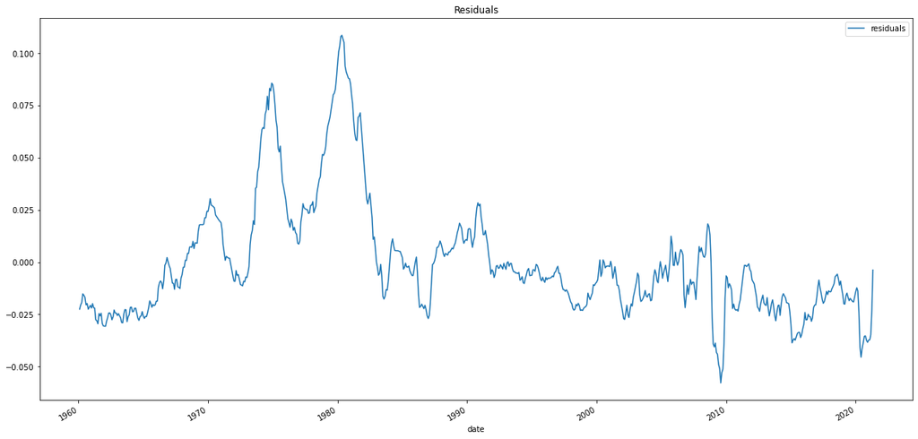

```python
h = 12
inflation_lagged = build_dataset(h, macro)
results = fit_model(inflation_lagged['y'], inflation_lagged[['M2', 'CPI']])
residuals = pd.concat([inflation_lagged['date'], pd.DataFrame(model.resid, columns=['residuals'])], axis=1)
residuals.set_index('date').plot(title='Residuals', figsize=(20, 10))
```

b) Yes, there seems to have some amount of serial correlation. This is also confirmed by the value of the Durbin-Watson test which is $0.095$.  
c) The betas as well because with serial correlation the assumption that $\epsilon$ and the regressor are uncorrelated is broken.

# 3. Time-Series Model of Volatility

```python
r = sp500
volatility_df = pd.DataFrame(r.Date, columns=['Date']).iloc[61:].set_index('Date')
```

##### Expanding series

```python
column_name = 'expanding_window'
def compute_var(values):
    return (values**2).sum() / len(values)
expanding_series_df = r.copy().set_index('Date').expanding(min_periods=61).apply(compute_var).shift(1).dropna()
volatility_df[column_name] = np.sqrt(expanding_series_df.SPY.values)

vol = volatility_df[:'2008-10-31'].iloc[-1][column_name]; print(f"Volatility on October 2008:\t{vol:.6f}")
vol = volatility_df[:'2020-04-30'].iloc[-1][column_name]; print(f"Volatility on April 2020:\t{vol:.6f}")
vol = volatility_df[:'2022-05-31'].iloc[-1][column_name]; print(f"Volatility on May 2022:\t\t{vol:.6f}")
```

```
Volatility on October 2008:	0.040591
Volatility on April 2020:	0.042309
Volatility on May 2022:		0.043220
```

##### Rolling Window

```python
column_name = 'rolling_window'
def compute_var(values):
    return (values**2).sum() / len(values)
roling_window_df = r.set_index('Date').rolling(window=61).apply(compute_var).shift(1).dropna()
volatility_df[column_name] = np.sqrt(roling_window_df.SPY.values)

vol = volatility_df[:'2008-10-31'].iloc[-1][column_name]; print(f"Volatility on October 2008:\t{vol:.6f}")
vol = volatility_df[:'2020-04-30'].iloc[-1][column_name]; print(f"Volatility on April 2020:\t{vol:.6f}")
vol = volatility_df[:'2022-05-31'].iloc[-1][column_name]; print(f"Volatility on May 2022:\t\t{vol:.6f}")
```

```
Volatility on October 2008:	0.029947
Volatility on April 2020:	0.039193
Volatility on May 2022:		0.047886
```

##### IGARCH

```python
column_name = 'IGARCH'
theta = 0.97
sigma = [0.15/np.sqrt(12)]
for i in range(1, len(r)+1):
    sigma += [np.sqrt(theta*sigma[i-1]**2 + (1-theta)*r.iloc[i-1].SPY**2)]

volatility_df[column_name] = sigma[62:]

vol = volatility_df[:'2008-10-31'].iloc[-1][column_name]; print(f"Volatility on October 2008:\t{vol:.6f}")
vol = volatility_df[:'2020-04-30'].iloc[-1][column_name]; print(f"Volatility on April 2020:\t{vol:.6f}")
vol = volatility_df[:'2022-05-31'].iloc[-1][column_name]; print(f"Volatility on May 2022:\t\t{vol:.6f}")
```

```
Volatility on October 2008:	0.046590
Volatility on April 2020:	0.048550
Volatility on May 2022:		0.047759
```

##### GARCH(1,1)

```python
column_name = 'GARCH'
am = arch_model(r.SPY)
forecasts = []
for i in range(61, len(r)):
    res = am.fit(first_obs=0, last_obs=i+1, disp="off")
    temp = res.forecast(horizon=1, reindex=False).variance
    fcast = temp.iloc[0]
    forecasts += [fcast.values[0]]

volatility_df[column_name] = np.sqrt(forecasts)

vol = volatility_df[:'2008-10-31'].iloc[-1][column_name]; print(f"Volatility on October 2008:\t{vol:.6f}")
vol = volatility_df[:'2020-04-30'].iloc[-1][column_name]; print(f"Volatility on April 2020:\t{vol:.6f}")
vol = volatility_df[:'2022-05-31'].iloc[-1][column_name]; print(f"Volatility on May 2022:\t\t{vol:.6f}")
```

```
Volatility on October 2008:	0.091378
Volatility on April 2020:	0.084973
Volatility on May 2022:		0.051495
```

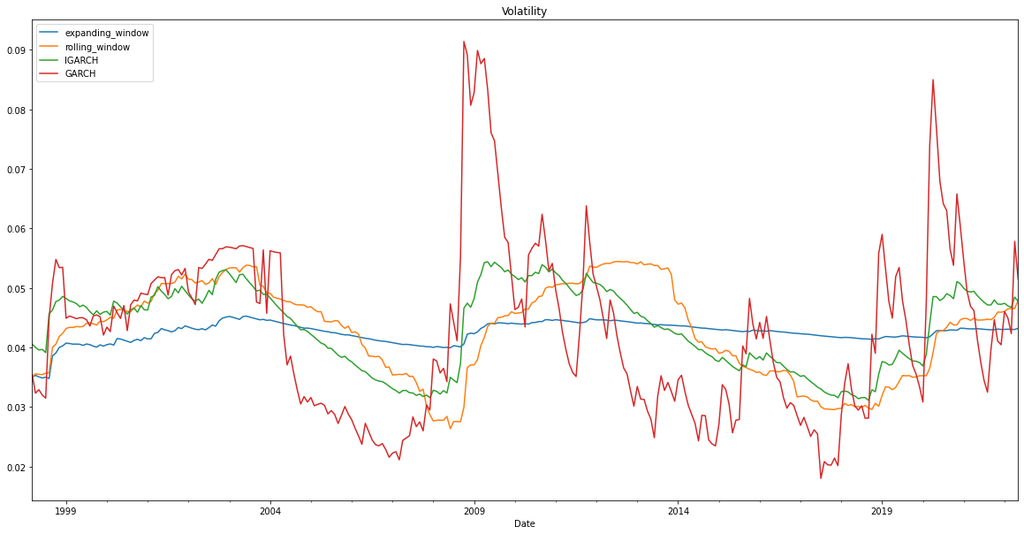

```python
volatility_df.plot(title='Volatility', figsize=(20, 10))
```